# Short report on campaign 01

11/07/2023 - 13/08/2023

*Last update: 10/09/2025*

## Introduction

The collection of field data is an important element of the HydroCORE project. It allows to make an assessment of the state of the Paute river system and to identify patterns in both space and time. It is expected that these conditions change along the path of the Paute river due to a variety of human and natural influences. For instance, the city of Cuenca is situated in the upstream part of the basin, while two reservoirs are present in the downstream part prior to entering the Amazon region.

To characterise the Paute river system, the HydroCORE project foresees a total of eight sampling campaigns over a period of two years. Abiotic conditions are recorded every three months and supplemented with the collection of macroinvertebrates every six months. At the spatial level, the project aims to include 20 reservoir sites and 30 river sites (totaling 50 sampling sites). These also include sites that are part of a reference system in which no artificial reservoirs are present, being the Jubones river system.

The first sampling campaign was performed from 11 July 2023 until 13 August 2023. During this period, a total of 49 sampling sites were visited. The results of the abiotic analyses performed both *on-site* (observations of the field conditions, probe readings) as *off-site* (nutrient analyses) are reported here in a concise manner. More results (e.g., macroinvertebrates) will be added later.

## Map of the sampling sites

A total of 49 sampling sites were visited and distributed as follows: (1) 19 river sites, (2) 19 reservoir sites, and (3) 11 reference system sites. The majority of the river sites (*N* = 14) is located upstream of the two reservoirs, while the majority of the reservoir sites (*N* = 14) is located in the largest reservoir (called Mazar). Relatively few reservoir sites (*N* = 5) were visited in the smaller reservoir (called Amaluza) due to accessibility reasons. There are hardly roads leading to the reservoir due to the steep mountains and a large fraction of the water surface is overcrowded by water hyacinth (*E. crassipes*). The map shows where the sampling sites are situated:

[interactive chart not shown]

Figure 1: Map of the sampling locations.

## Physicochemical conditions

At every sampling site, a series of water quality parameters were recorded. In addition, water samples were collected in plastic bottles for nutrient analysis in the lab at UCuenca. Within this section, the results of these analyses are presented in a concise manner and further explored through principal component analysis and hierarchical clustering. Through this exploration, similarities and dissimilarities between sampling sites can be observed.

### Statistical summary

A first step in the data exploration is looking at the characteristic statistics of the considered variables. This provides an idea of the range of the obtained values and indicates if (and where) data is missing. For this overview, a distinction is made between the parameters measured *on-site* and *off-site*.

Table 1: Summary of the on- and off-site variables

|  | Min | Q1 | Median | Q3 | Max | Mean | SD | #NA |
| --- | --- | --- | --- | --- | --- | --- | --- | --- |
| Altitude [m a.s.l.] | 915.00 | 1989.00 | 2153.00 | 2213.00 | 3105.00 | 2098.47 | 395.10 | 0 |
| Distance | 0.35 | 37.82 | 51.66 | 68.78 | 143.08 | 57.76 | 33.03 | 0 |
| Temperature [oC] | 11.00 | 14.01 | 16.31 | 17.66 | 22.31 | 16.03 | 2.66 | 0 |
| pH [-] | 6.70 | 7.40 | 7.97 | 8.38 | 9.51 | 7.93 | 0.66 | 0 |
| Conductivity [mS/cm] | 0.00 | 0.11 | 0.21 | 0.25 | 1.16 | 0.23 | 0.19 | 0 |
| Salinity [ppt] | 0.00 | 0.00 | 0.10 | 0.10 | 0.60 | 0.10 | 0.10 | 0 |
| Oxygen saturation [%] | 24.20 | 92.80 | 102.70 | 116.70 | 155.80 | 102.46 | 24.93 | 0 |
| Oxygen [mg/L] | 2.48 | 8.40 | 9.62 | 10.94 | 13.43 | 9.55 | 2.21 | 0 |
| Total dissolved solids [g/L] | 0.00 | 0.09 | 0.15 | 0.17 | 0.74 | 0.16 | 0.12 | 2 |
| Oxidation reduction potential [ORPmV] | 218.00 | 268.50 | 298.00 | 327.50 | 397.00 | 297.65 | 47.51 | 6 |
| Turbidity [NTU] | 0.10 | 3.50 | 4.80 | 11.70 | 384.00 | 19.90 | 57.38 | 4 |
| Chlorophyll a [ug/L] | 5.95 | 22.42 | 31.37 | 49.11 | 132.67 | 37.81 | 25.71 | 0 |
| Average velocity [m/s] | 0.00 | 0.00 | 0.03 | 0.36 | 1.21 | 0.22 | 0.30 | 6 |
| TOC [mg/L] | 1.38 | 3.04 | 3.72 | 5.69 | 24.86 | 5.37 | 4.70 | 1 |
| TIC [mg/L] | 2.08 | 7.72 | 9.50 | 11.56 | 25.55 | 10.01 | 4.37 | 3 |
| Total carbon [mg/L] | 0.80 | 10.67 | 12.89 | 17.31 | 39.15 | 14.68 | 7.16 | 0 |
| Nitrate-N [mg/L] | 0.50 | 0.50 | 0.50 | 0.62 | 1.16 | 0.60 | 0.17 | 0 |
| Nitrite-N [mg/L] | 0.02 | 0.02 | 0.02 | 0.02 | 0.13 | 0.03 | 0.03 | 0 |
| Ammonium-N [mg/L] | 0.05 | 0.05 | 0.05 | 0.07 | 1.78 | 0.19 | 0.36 | 0 |
| Orthophosphate-P [mg/L] | 0.05 | 0.05 | 0.05 | 0.08 | 0.25 | 0.08 | 0.06 | 0 |
| Total-N [mg/L] | 0.50 | 0.56 | 0.85 | 1.28 | 2.76 | 1.03 | 0.57 | 0 |
| Total-P [mg/L] | 0.05 | 0.05 | 0.05 | 0.11 | 0.60 | 0.11 | 0.11 | 0 |

### Correlation analysis

The different variables of the previous sections were used as a basis for a correlation analysis (see Figure 2). From this analysis, it is clear that some variables are more correlated than others (as is expected). Salinity, conductivity, and total dissolved solids show a higher-than-average correlation as they more or less reflect the amount of dissolved chemicals in the water column. Also the different nutrients display a higher correlation, with the exception of nitrate-nitrogen. The latter might be related to the relatively low variability in the observed value due to the quantification limit of 0.5 mgN/L used during the analysis (see Table 1).

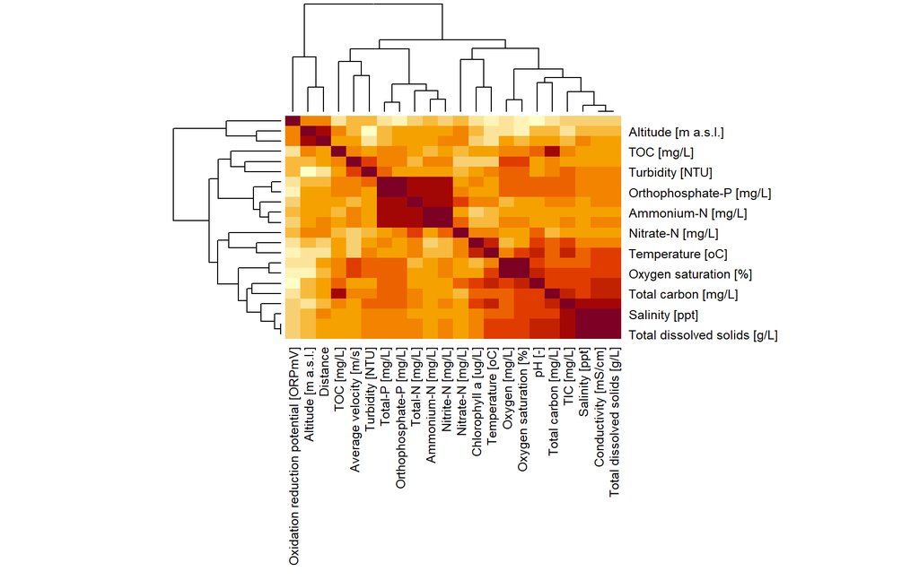

Figure 2: Correlation analysis of the various variables.

### Principal component analysis

The PCA shows that the majority of sampling sites cluster together (see Figure 3), which is partially in line with the observed nutrient levels (see Table 1). Sites that showed discrepancy from the majority of the sites included the Paute river (code ‘PA’) and Giron sites (code ‘GI’), displaying relatively higher nutrient levels.

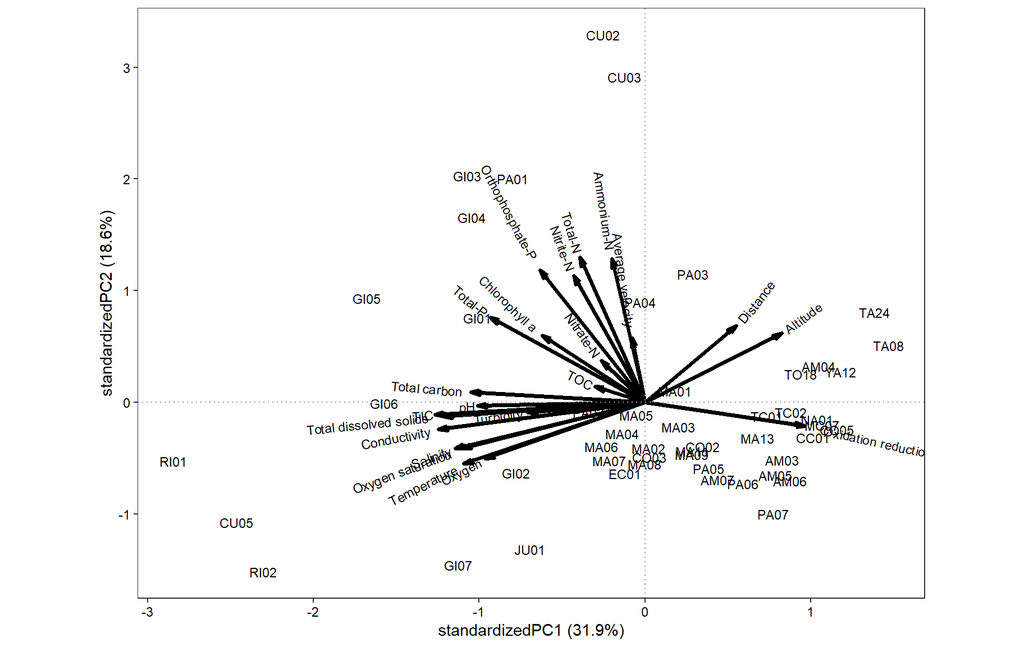

Figure 3: PCA of the physicochemical data.

### Supervised clustering

In addition to the unsupervised analysis provided by PCA, a supervised cluster analysis can be performed to identify (dis)similarities between sampling sites. These (dis)similarities can be calculated through distances, with the Euclidean distance being the most frequently used. Subsequently, clusters are created based on these distances by using a specific linkage technique. Here, Euclidean distances and a complete linkage is being used.

The resulting hierarchical tree displays the closeness of the different sampling sites and shows that spatially close sites do not always cluster together (see Figure 4). Some closely situated sites do cluster together (e.g., CU02/03, TA08/24, AM03/04, AM05/06), while others end up further away in the tree (e.g., MA11/13, GI02/03, RI01/02). Some overlap with the PCA result can also be seen, including the similarity between GI03 and GI04 and the discrepancy with the majority of sampling sites.

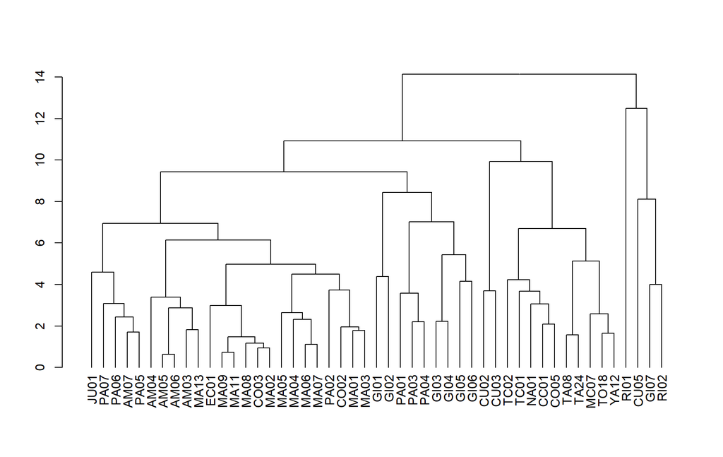

Figure 4: Hierarchical clustering of the sample sites.

## Greenhouse gases

Aside from the abovementioned physicochemical conditions, additional samples were collected to determine (1) the presence of greenhouse gases in a dissolved state within the water column and (2) the emission of greenhouse gases to the atmosphere. Samples were collected in 12 mL glass vials that were pre-rinsed with Helium and subsequently analysed at ETH Zürich. Within this section, the results of these analyses are presented in a concise manner and further explored through principal component analysis and hierarchical clustering. Through this exploration, similarities and dissimilarities between sampling sites can be observed.

### Statistical summary

Similar to the section on the physicochemical conditions, we start with a look at the characteristic statistics of the considered variables. For this overview, a distinction is made between dissolved greenhouse gases and the calculated emissions.

An overall summary is given in Table 2, showing that the level of carbon dioxide in the water column ranged from 13.92 µM up to 141.02 µM, averaging at 41.33 µM (SD = 23.78 µM). Methane levels ranged from 0.07 µM up to 3.21 µM and averaged at 0.36 µM (SD = 0.54 µM). Nitrous oxide levels showed to be relatively uniform and clearly lower than the carbon-based gases.

In addition, Table 2 also contains a summary of the emitted greenhouse gases. Especially interesting here is the negative flux for carbon dioxide (at -608 mg/m²/d), suggesting a local net uptake of carbon dioxide. Also the maximum emission rate for both carbon dioxide (3920 mg/m²/d) and methane (1193 mg/m²/d) are worth mentioning, though they might be influenced by ebullition taking place right under the collecting chamber.

Table 2: Summary of the dissolved and emitted greenhouse gases.

|  | Min | Q1 | Median | Q3 | Max | Mean | SD | #NA |
| --- | --- | --- | --- | --- | --- | --- | --- | --- |
| Nitrous oxide [uM] | 0.02 | 0.02 | 0.02 | 0.02 | 0.04 | 0.02 | 0.00 | 0 |
| Methane [uM] | 0.07 | 0.09 | 0.13 | 0.42 | 3.21 | 0.36 | 0.54 | 0 |
| Carbon dioxide [uM] | 13.92 | 26.15 | 32.56 | 48.96 | 141.02 | 41.33 | 23.78 | 0 |
| Nitrous oxide [mg/m²/d] | 0.00 | 0.02 | 0.06 | 0.11 | 0.80 | 0.11 | 0.17 | 10 |
| Carbon dioxide [mg/m²/d] | -608.14 | 78.17 | 328.24 | 764.52 | 3920.31 | 537.80 | 763.47 | 8 |
| Methane [mg/m²/d] | -0.05 | 0.26 | 0.98 | 5.42 | 1193.20 | 38.92 | 185.76 | 7 |

### Correlation analysis

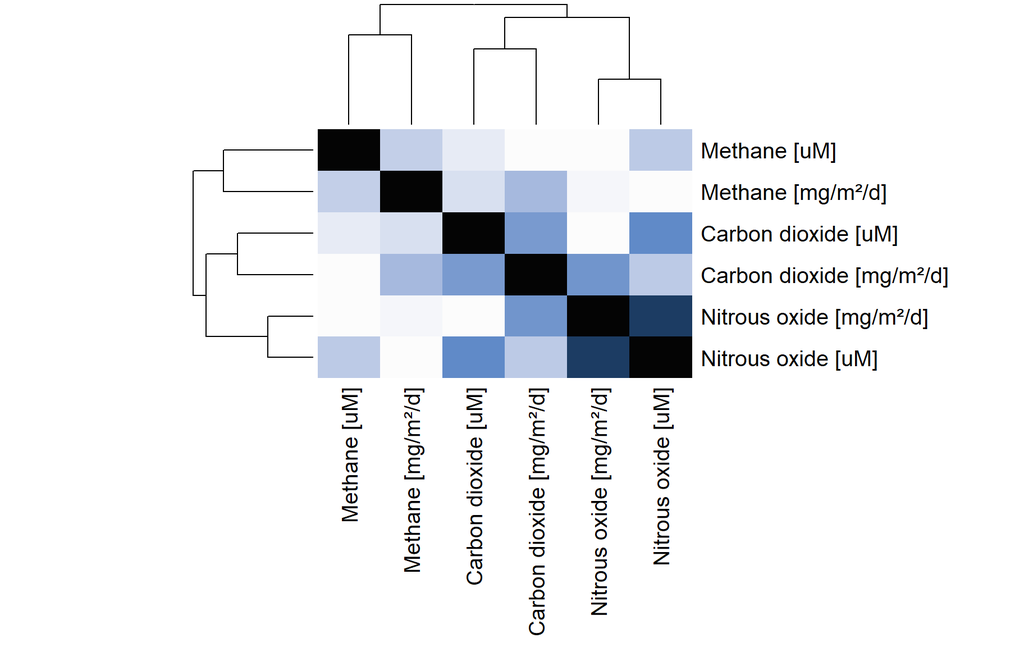

Figure 5: Correlation analysis of the greenhouse gases.

### Principal component analysis

In alignment with the physicochemical conditions, dimensionality reduction can be applied. Principal component analysis (PCA) shows that the first component is mostly determined by all of the greenhouse gases and that the second principal component allows for a further finetuning related to nitrous oxide and methane.

The PCA shows that the majority of sampling sites cluster together (see Figure 6). Sites that showed discrepancy from the majority of the sites included the Cuenca and Paute river (codes ‘CU’ and ‘PA’) and Giron sites (code ‘GI’), as well as some sites in the upstream part of the Amaluza (code ‘AM’) and Mazar (code ‘MA’) reservoir. These sites are characterised by a relatively high emission of the considered greenhouse gases.

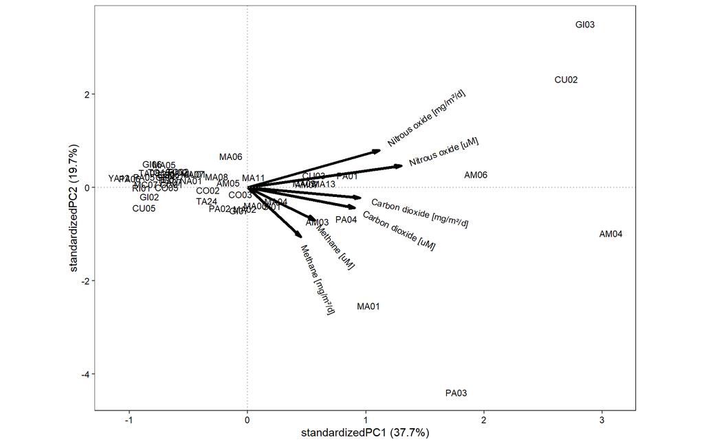

Figure 6: PCA of the greenhouse gas data.

### Supervised clustering

In addition to the unsupervised analysis provided by PCA, the supervised cluster analysis displays the closeness of the different sampling sites and shows that spatially close sites do not always cluster together (see Figure 7). Some closely situated sites do cluster together (e.g., MA02/03, TC01/02, RI01/02), while others end up further away in the tree (e.g., MA11/13, GI02/03, MA01/02). Some overlap with the PCA result can also be seen, including the discrepancy of AM04, CU02, GI03, MA01, and PA03 with the majority of sampling sites.

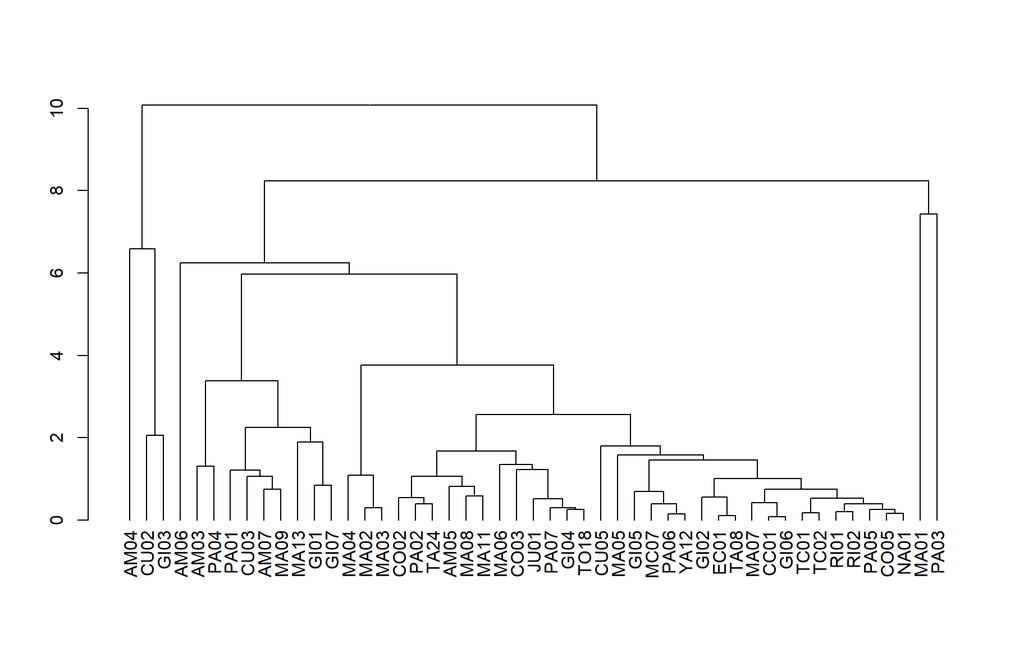

Figure 7: Hierarchical clustering of the sample sites.

## Summary

A total of 49 sampling sites were selected and assessed for a variety of water quality parameters and a set of greenhouse gases. Surprisingly, the majority of sampling sites showed nutrient levels that were below the limit of quantification. This limits the variability between sampling sites as displayed through PCA and cluster analysis. Only a few sampling sites seem to show different conditions, most of them located near or downstream of urbanisation. For example, the Paute sites are situated downstream of Cuenca, while the Giron sites are situated in and downstream of the town of Giron. Some of these sites also display an elevated presence and emission of greenhouse gases, resulting in a clear distance from the other sites in the PCA and cluster analyses.

## Acknowledgement

We would like to thank L.T. Ho, G.D. Panique Casso, P.V. Mosquera, K.P. Chavez Loja, P.N. Abad Merchán, M.J. Gallegos Ochoa, G.E. Malla, C.F. Sanchez, and K.P. Ramirez for their help in collecting the samples in the field as well as their subsequent processing in the lab. We also thank D.G. Zuñiga Villegas for providing us with the necessary transport and M. Barthel for the analyses of the greenhouse gas samples.

## Reference

Van Echelpoel, W. (2025). *Short report on campaign 01*. HydroCORE project. Online: https://wvechelp.github.io/HydroCORE/Reports/ShortReportCampaign01.html

Read more on the [HydroCORE webpage](https://wvechelp.github.io/HydroCORE/).